# Filter/joins (like VLOOKUP in Excel)

## Attach packages:

tidyverse, readxl, here

Read in 3 files and store them as objects

- invert_counts_curated.xlsx
- fish_counts_curated.csv
- kelp_counts_curated.xlsx

```r
invert_counts <- read_excel(here("R-workshop-data", "invert_counts_curated.xlsx"))

fish_counts <- read_csv(here("R-workshop-data", "fish_counts_curated.csv"))
kelp_counts_abur <- read_excel(here("R-workshop-data", "kelp_counts_curated.xlsx"))
```

- select() function: keep, exclude or rearrange COLUMNS
- filter() function: keeps or excludes ROWS (observations) based on whether or not they match variable conditions

## Filter to match rows based on a character string

Only keep observations from fish_counts where the common_name variable matches “garibaldi”

```r
fish_garibaldi <-fish_counts %>%
  filter(common_name == "garibaldi")

# Use janitor::clean_names() to automatically update all of your column names to lowercase_snake_case
```

## Filter to keep or exclude observations based on numeric conditions

Create a subset where total_counts is greater than or equal to 50:

```r
fish_over50 <- fish_counts %>%
  filter(total_count >= 50)
```

Create a subset that only contains observations for fish at Mohawk Reef (“mohk”):

```r
mohawk_fish <-fish_counts %>%
  filter(site == "mohk")
```

## Filter to keep rows that match THIS or THAT

Example: We want to keep any observations for garibaldi, blacksmith, or black surfperch

Use the %in% operator to look for any matches within a vector

```r
fish_3sp <- fish_counts %>%
  filter(common_name %in% c("garibaldi", "blacksmith", "black surfperch"))

# Writing the or statements explicitly:
# Use the vertical line | to indicate "or"

fish_3sp_v2 <- fish_counts %>%
  filter(common_name == "garibaldi" | common_name == "blacksmith" | common_name == "black surfperch")
```

## Filter to return rows that match conditions for MULTIPLE variables (AND statements)

I want to create a subset called urchin_abur_mohk thtat only keeps observations where:

- site is “abur” or “mohk” AND
- species is “purple urchin”

Some ways to do this:

- separate “AND” conditions within a single filter line by a comma
- separate “AND” conditions within a single filter line by an ampersand (&)
- putting each filter condition within a separate filter line

Reminder: “OR” %in% Remember: if filtering with pipe, the order matters.

```r
urchin_abur_mohk <- invert_counts %>%
  filter(site %in% c("abur", "mohk"), common_name == "purple urchin")

# EXAMPLE PIPE ORDER
# pipe_test <- fish_counts %>%
#  select(common_name, total_count) %>%
#  filter(year == 2016)
```

Activity: create a subset from fish_counts called low_gb_rw that only contains:

- observations for “garibaldi” and “rock wrasse”
- where the total_count is LESS than 10

```r
low_gb_rw <- fish_counts %>%
  filter(common_name %in% c("garibaldi", "rock wrasse"),
         total_count < 10)
```

## Filter rows that DO NOT MATCH conditions

Use != (indicates “does NOT match”)

Try to create a subset from fish_counts that does NOT contain observations for Mohawk Reef (“mohk”)

```r
fish_no_mohk <- fish_counts %>%
  filter(site != "mohk")
```

An example of filter as part of a piped sequence:

```r
senorita_allyears <- fish_counts %>%
  filter (common_name == "senorita") %>%
  group_by(site) %>%
  summarize(count_all_years = sum(total_count))
```

## A couple ways of joining data frames

- ‘full_join()’: keeps everything (safe join) i.e. you don’t have to have any matches in order to join
- ‘left_join()’: If we are merging A and B, will only retain observations from B that have matches in A

```r
fish_2016_2017 <- fish_counts %>%
  filter(year == 2016 | year == 2017)
```

Join that data frame with kelp_counts_abur:

```r
#abur_kelp_join <- fish_2016_2017 %>%
#  full_join(kelp_counts_abur, by = c("year", "site"))
```

```r
kelp_counts_abur <- kelp_counts_abur %>%
  mutate(year = as.numeric(year))

class(kelp_counts_abur$year)
```

```
## [1] "numeric"
```

Now we can join them:

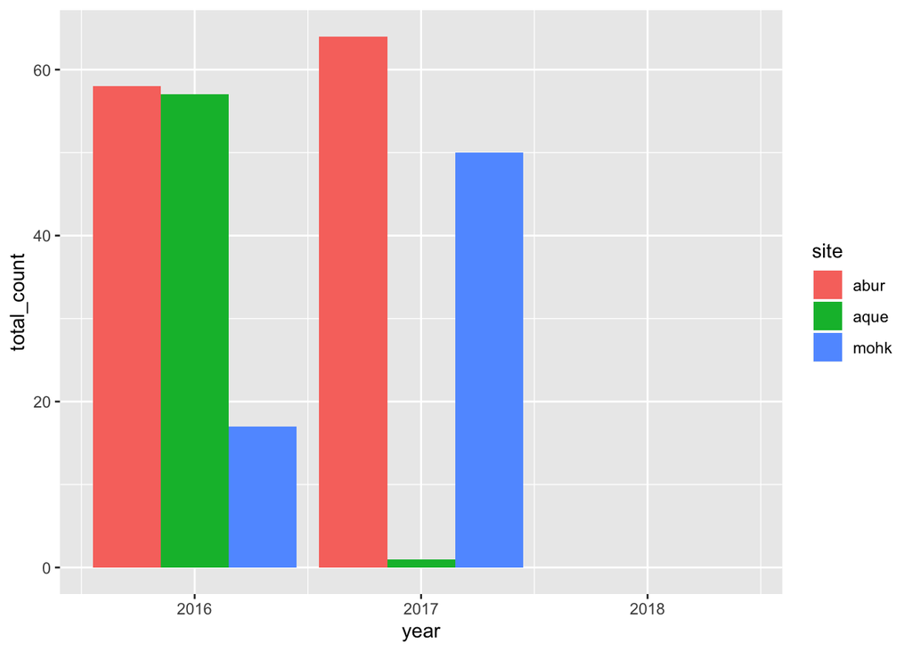

```r
abur_kelp_join <- fish_2016_2017 %>%
  full_join(kelp_counts_abur, by = c("year", "site"))

ggplot(abur_kelp_join, aes(x = year, y = total_count)) +
  geom_col(aes(fill = site), position = "dodge")
```